# Algerian Forest Fires

### Whole Region

```r
suppressWarnings({

#remove the warning that we get considering it is a perfect separation

allRegionTrainData$Classes <- as.factor(trimws(allRegionTrainData$Classes))
allRegionTestData$Classes <- as.factor(trimws(allRegionTestData$Classes))
#remove the spaces to avoid dividing it into more than 2 categories

levels(allRegionTrainData$Classes) <- c('fire','not_fire')
levels(allRegionTestData$Classes) <- c('fire','not_fire')
#rename the labels to avoid getting errors from having a space in "not fire"

library(caret)
library(MASS)
#QDA fitting
qda_fit = qda(Classes ~ .-day-month-Ws-RH, data = tempWholeRegionData, susbet = allRegionTrainData)
qda_fit

#prediction the test set
qda_pred = predict(qda_fit, allRegionTestData)
qda_class <- qda_pred$class

#Confusion matrix
table(qda_class,allRegionTestData$Classes)
#confusionMatrix(tempWholeRegionData$Classes, qda_class)
})
```

```
##
## qda_class fire not_fire
##         1   61        2
##         2    0       59
```

```r
qda_model = qda(Classes ~ .-day-month-Ws-RH, data = tempWholeRegionData, susbet = allRegionTrainData)
qda_pred = predict(qda_model, allRegionTestData)
qda_class = qda_pred$class
table(qda_class, allRegionTestData$Classes)
```

```
##
## qda_class fire not_fire
##         1   61        2
##         2    0       59
```

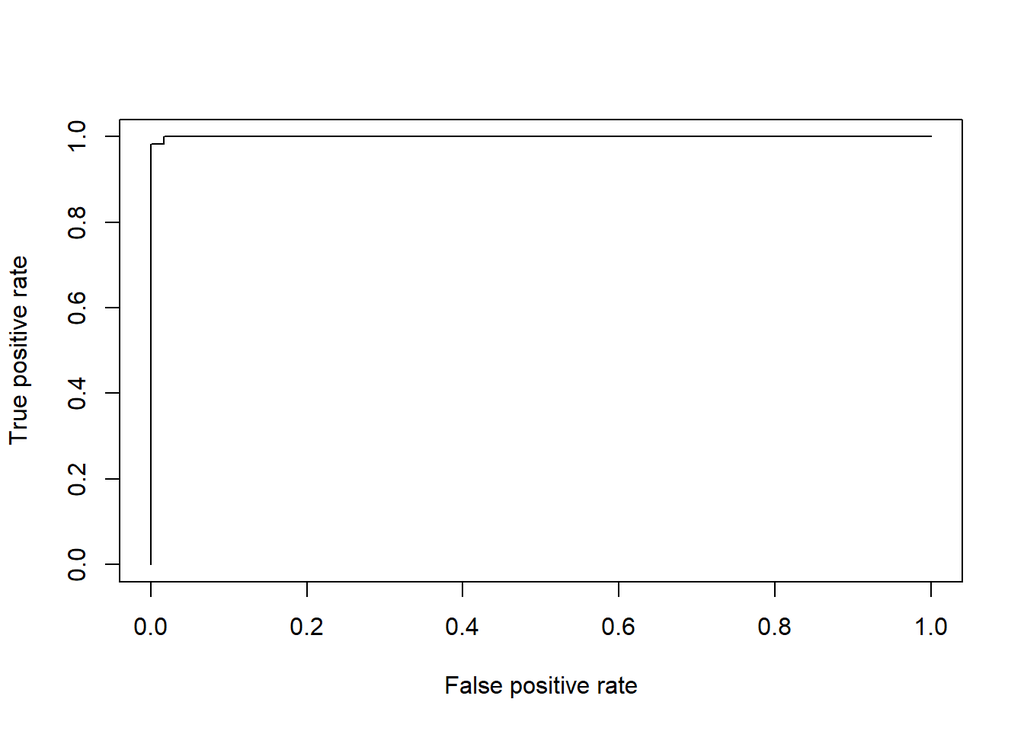

```r
qda_prediction <- prediction(qda_pred$posterior[,2], allRegionTestData$Classes)
perf <- performance(qda_prediction, "tpr", "fpr")
plot(perf)
```

```r
auc <- performance(qda_prediction, measure = "auc")
auc <- auc@y.values[[1]]
print(auc)
```

```
## [1] 0.9997313
```

The results show that the performance of the QDA model applied on the whole regions is way higher than the one of the LDA, where the AUC was nearly 52%. However, here in our case the performance is almost the highest between all the other methods being generated on different regions with AUC = 99.97%. This shows that QDA method applied on region1, region2, and whole region is performing the best. QDA is outperforming LDA, especially that the balance is seen in the QDA model results where all values of AUC of the ROC curve are above 99.8%.

## KNN

### Region 1

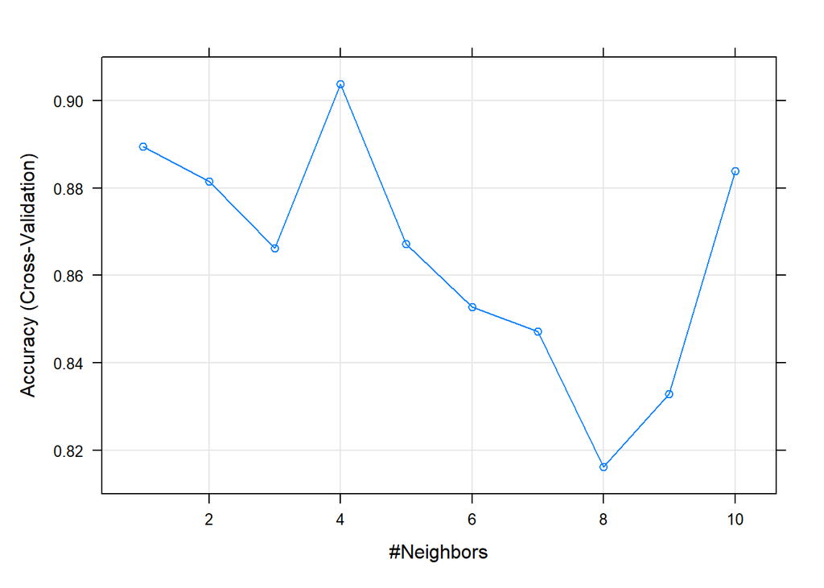

```r
set.seed(55)

region1KnnModel <- train(Classes ~ ., data=region1TrainData, method="knn",  tuneGrid=expand.grid(k = 1:10), trControl=LRspecs)
#applying KNN with k=10

plot(region1KnnModel)
```

```r
#plot k based on accuracy

region1KnnModel
## k-Nearest Neighbors
##
## 61 samples
## 13 predictors
##  2 classes: 'fire', 'not_fire'
##
## No pre-processing
## Resampling: Cross-Validated (10 fold)
## Summary of sample sizes: 54, 55, 56, 55, 55, 56, ...
## Resampling results across tuning parameters:
##
##   k   Accuracy   Kappa
##    1  0.8895238  0.7755979
##    2  0.8814286  0.7606667
##    3  0.8661905  0.7305385
##    4  0.9038095  0.8025385
##    5  0.8671429  0.7259044
##    6  0.8528571  0.6979044
##    7  0.8471429  0.6880256
##    8  0.8161905  0.6266923
##    9  0.8328571  0.6660256
##   10  0.8838095  0.7745641
##
## Accuracy was used to select the optimal model using the largest value.
## The final value used for the model was k = 4.
#show the results and get best k that was used to train the model

predictions = predict(region1KnnModel, newdata = region1TestData)
#predict based on the trained model

knn1MatrixR1 = confusionMatrix(data=predictions,region1TestData$Classes)

knn1MatrixR1
## Confusion Matrix and Statistics
##
##           Reference
## Prediction fire not_fire
##   fire       32        8
##   not_fire    1       20
##
##                Accuracy : 0.8525
##                  95% CI : (0.7383, 0.9302)
##     No Information Rate : 0.541
##     P-Value [Acc > NIR] : 2.6e-07
##
##                   Kappa : 0.6972
##
##  Mcnemar's Test P-Value : 0.0455
##
##             Sensitivity : 0.9697
##             Specificity : 0.7143
##          Pos Pred Value : 0.8000
##          Neg Pred Value : 0.9524
##              Prevalence : 0.5410
##          Detection Rate : 0.5246
##    Detection Prevalence : 0.6557
##       Balanced Accuracy : 0.8420
##
##        'Positive' Class : fire
##
knn1MatrixR1$byClass
```

```
##          Sensitivity          Specificity       Pos Pred Value
##            0.9696970            0.7142857            0.8000000
##       Neg Pred Value            Precision               Recall
##            0.9523810            0.8000000            0.9696970
##                   F1           Prevalence       Detection Rate
##            0.8767123            0.5409836            0.5245902
## Detection Prevalence    Balanced Accuracy
##            0.6557377            0.8419913
```

```r
#show confusion matrix and the values of the various metrics
```

The optimal k that was used for region 1 is k=4, the model gave a good accuracy, recall and precision. The numbers are 85.2%, 96.9% and 80% respectively. We will try to apply feature selection to achieve better precision.

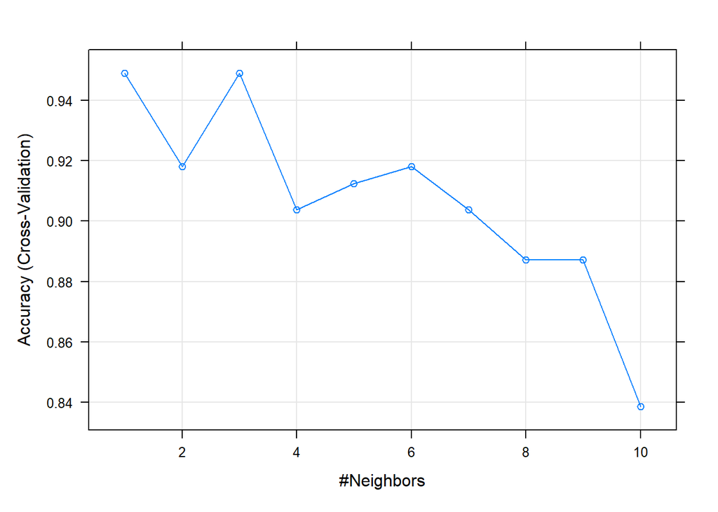

```r
region1KnnModel2 <- train(Classes ~ Temperature+Rain+FFMC+DMC+DC+ISI+BUI+FWI, data=region1TrainData, method="knn",  tuneGrid=expand.grid(k = 1:10), trControl=LRspecs)

plot(region1KnnModel2)
```

```r
region1KnnModel2
## k-Nearest Neighbors
##
## 61 samples
##  8 predictor
##  2 classes: 'fire', 'not_fire'
##
## No pre-processing
## Resampling: Cross-Validated (10 fold)
## Summary of sample sizes: 54, 56, 54, 55, 56, 54, ...
## Resampling results across tuning parameters:
##
##   k   Accuracy   Kappa
##    1  0.9490476  0.8977703
##    2  0.9180952  0.8340022
##    3  0.9490476  0.8977703
##    4  0.9038095  0.8084370
##    5  0.9123810  0.8284103
##    6  0.9180952  0.8388718
##    7  0.9038095  0.8084370
##    8  0.8871429  0.7751037
##    9  0.8871429  0.7751037
##   10  0.8385714  0.6775944
##
## Accuracy was used to select the optimal model using the largest value.
## The final value used for the model was k = 3.

predictions = predict(region1KnnModel2, newdata = region1TestData)

knn1MatrixR1 = confusionMatrix(data=predictions,region1TestData$Classes)

knn1MatrixR1
## Confusion Matrix and Statistics
##
##           Reference
## Prediction fire not_fire
##   fire       32        4
##   not_fire    1       24
##
##                Accuracy : 0.918
##                  95% CI : (0.819, 0.9728)
##     No Information Rate : 0.541
##     P-Value [Acc > NIR] : 1.542e-10
##
##                   Kappa : 0.8336
##
##  Mcnemar's Test P-Value : 0.3711
##
##             Sensitivity : 0.9697
##             Specificity : 0.8571
##          Pos Pred Value : 0.8889
##          Neg Pred Value : 0.9600
##              Prevalence : 0.5410
##          Detection Rate : 0.5246
##    Detection Prevalence : 0.5902
##       Balanced Accuracy : 0.9134
##
##        'Positive' Class : fire
##
knn1MatrixR1$byClass
```

```
##          Sensitivity          Specificity       Pos Pred Value
##            0.9696970            0.8571429            0.8888889
##       Neg Pred Value            Precision               Recall
##            0.9600000            0.8888889            0.9696970
##                   F1           Prevalence       Detection Rate
##            0.9275362            0.5409836            0.5245902
## Detection Prevalence    Balanced Accuracy
##            0.5901639            0.9134199
```

The optimal k this time is k=3, the model gave a better accuracy(91.8%) and precision(88.8%), and similar recall(96.9%). As such, using less features in the case of KNN gave us better results, thus improving our predictions.

### Region 2

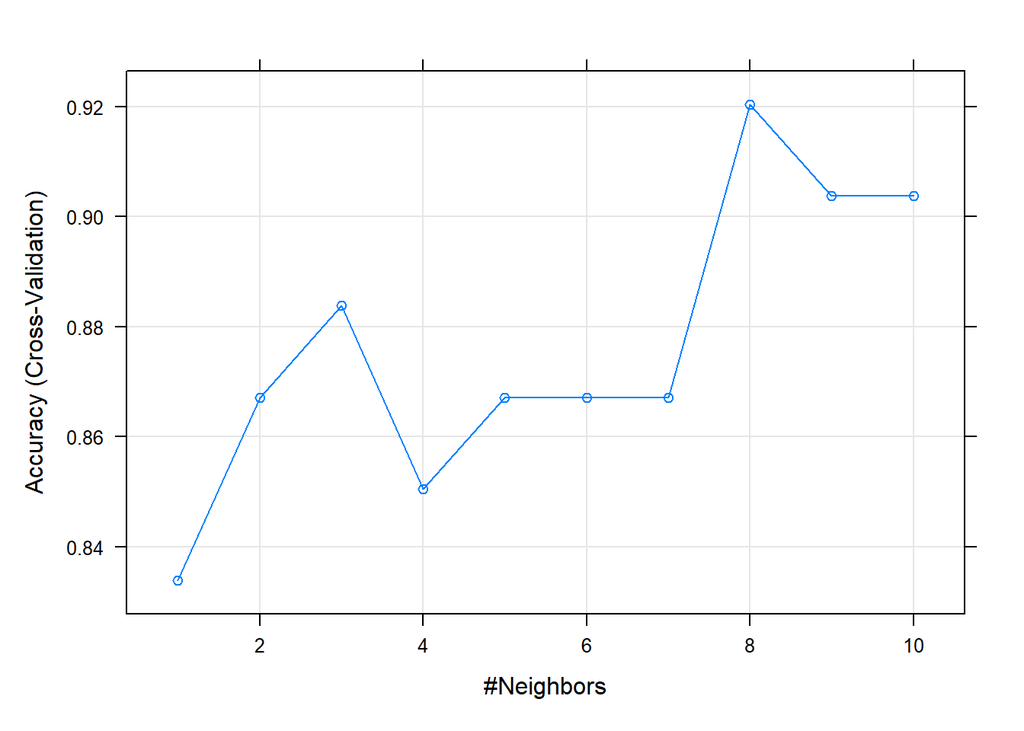

```r
region2KnnModel <- train(Classes ~ ., data=region2TrainData, method="knn",  tuneGrid=expand.grid(k = 1:10), trControl=LRspecs)

plot(region2KnnModel)
```

```r
region2KnnModel
## k-Nearest Neighbors
##
## 61 samples
## 13 predictors
##  2 classes: 'fire', 'not_fire'
##
## No pre-processing
## Resampling: Cross-Validated (10 fold)
## Summary of sample sizes: 55, 56, 55, 55, 54, 55, ...
## Resampling results across tuning parameters:
##
##   k   Accuracy   Kappa
##    1  0.8338095  0.6440779
##    2  0.8671429  0.7286017
##    3  0.8838095  0.7619351
##    4  0.8504762  0.6952684
##    5  0.8671429  0.7190779
##    6  0.8671429  0.7190779
##    7  0.8671429  0.7190779
##    8  0.9204762  0.8270450
##    9  0.9038095  0.7949021
##   10  0.9038095  0.7949021
##
## Accuracy was used to select the optimal model using the largest value.
## The final value used for the model was k = 8.

predictions = predict(region2KnnModel, newdata = region2TestData)
knn1MatrixR2 = confusionMatrix(data=predictions,region2TestData$Classes)

knn1MatrixR2
## Confusion Matrix and Statistics
##
##           Reference
## Prediction fire not_fire
##   fire       37        2
##   not_fire    4       18
##
##                Accuracy : 0.9016
##                  95% CI : (0.7981, 0.963)
##     No Information Rate : 0.6721
##     P-Value [Acc > NIR] : 2.824e-05
##
##                   Kappa : 0.7824
##
##  Mcnemar's Test P-Value : 0.6831
##
##             Sensitivity : 0.9024
##             Specificity : 0.9000
##          Pos Pred Value : 0.9487
##          Neg Pred Value : 0.8182
##              Prevalence : 0.6721
##          Detection Rate : 0.6066
##    Detection Prevalence : 0.6393
##       Balanced Accuracy : 0.9012
##
##        'Positive' Class : fire
##
knn1MatrixR2$byClass
```

```
##          Sensitivity          Specificity       Pos Pred Value
##            0.9024390            0.9000000            0.9487179
##       Neg Pred Value            Precision               Recall
##            0.8181818            0.9487179            0.9024390
##                   F1           Prevalence       Detection Rate
##            0.9250000            0.6721311            0.6065574
## Detection Prevalence    Balanced Accuracy
##            0.6393443            0.9012195
```

k=8 was the optimal k-value in region 2, giving us an accuracy of 90.1%, a recall of 90.2%, and a precision of 94.8%. These values are good considering we are using all features, but we will try and improve them further with feature selection.

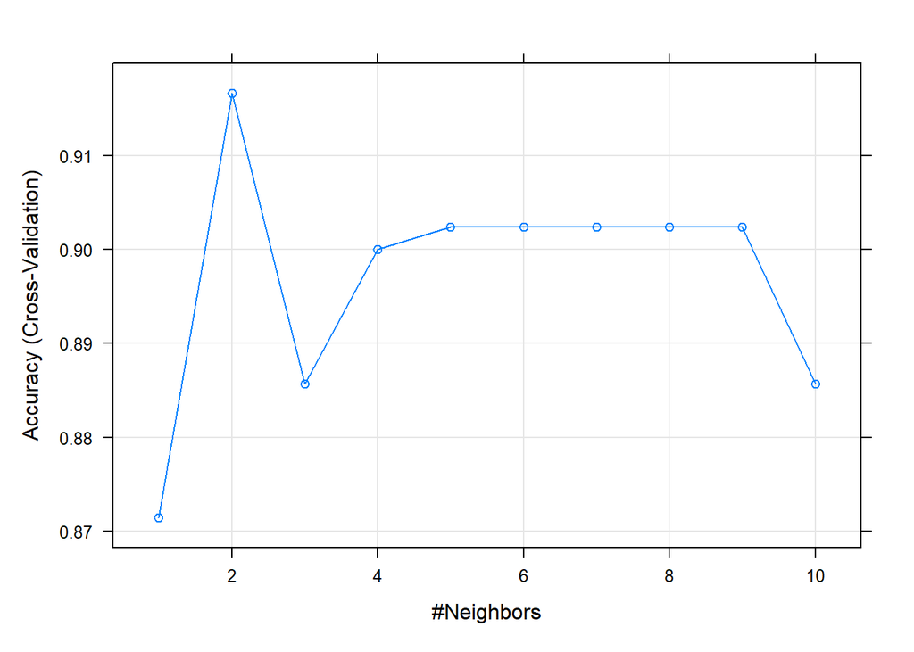

```r
region2KnnModel <- train(Classes ~ Temperature+Rain+FFMC+DMC+DC+ISI+BUI+FWI, data=region2TrainData, method="knn",  tuneGrid=expand.grid(k = 1:10), trControl=LRspecs)

plot(region2KnnModel)
```

```r
region2KnnModel
## k-Nearest Neighbors
##
## 61 samples
##  8 predictor
##  2 classes: 'fire', 'not_fire'
##
## No pre-processing
## Resampling: Cross-Validated (10 fold)
## Summary of sample sizes: 55, 55, 56, 55, 55, 54, ...
## Resampling results across tuning parameters:
##
##   k   Accuracy   Kappa
##    1  0.8714286  0.7226190
##    2  0.9166667  0.8238095
##    3  0.8857143  0.7624762
##    4  0.9000000  0.7904762
##    5  0.9023810  0.7958095
##    6  0.9023810  0.7958095
##    7  0.9023810  0.7958095
##    8  0.9023810  0.7958095
##    9  0.9023810  0.7958095
##   10  0.8857143  0.7386667
##
## Accuracy was used to select the optimal model using the largest value.
## The final value used for the model was k = 2.

predictions = predict(region2KnnModel, newdata = region2TestData)

knn1MatrixR1 = confusionMatrix(data=predictions,region2TestData$Classes)

knn1MatrixR1
## Confusion Matrix and Statistics
##
##           Reference
## Prediction fire not_fire
##   fire       40        2
##   not_fire    1       18
##
##                Accuracy : 0.9508
##                  95% CI : (0.8629, 0.9897)
##     No Information Rate : 0.6721
##     P-Value [Acc > NIR] : 1.385e-07
##
##                   Kappa : 0.887
##
##  Mcnemar's Test P-Value : 1
##
##             Sensitivity : 0.9756
##             Specificity : 0.9000
##          Pos Pred Value : 0.9524
##          Neg Pred Value : 0.9474
##              Prevalence : 0.6721
##          Detection Rate : 0.6557
##    Detection Prevalence : 0.6885
##       Balanced Accuracy : 0.9378
##
##        'Positive' Class : fire
##
knn1MatrixR1$byClass
```

```
##          Sensitivity          Specificity       Pos Pred Value
##            0.9756098            0.9000000            0.9523810
##       Neg Pred Value            Precision               Recall
##            0.9473684            0.9523810            0.9756098
##                   F1           Prevalence       Detection Rate
##            0.9638554            0.6721311            0.6557377
## Detection Prevalence    Balanced Accuracy
##            0.6885246            0.9378049
```

The optimal k this time is k=2, the model gave a better accuracy(95%), precision(95.2%), and recall(97.5%). As such, using less features in the case of KNN gave us better results, thus improving our predictions.

### Whole Region

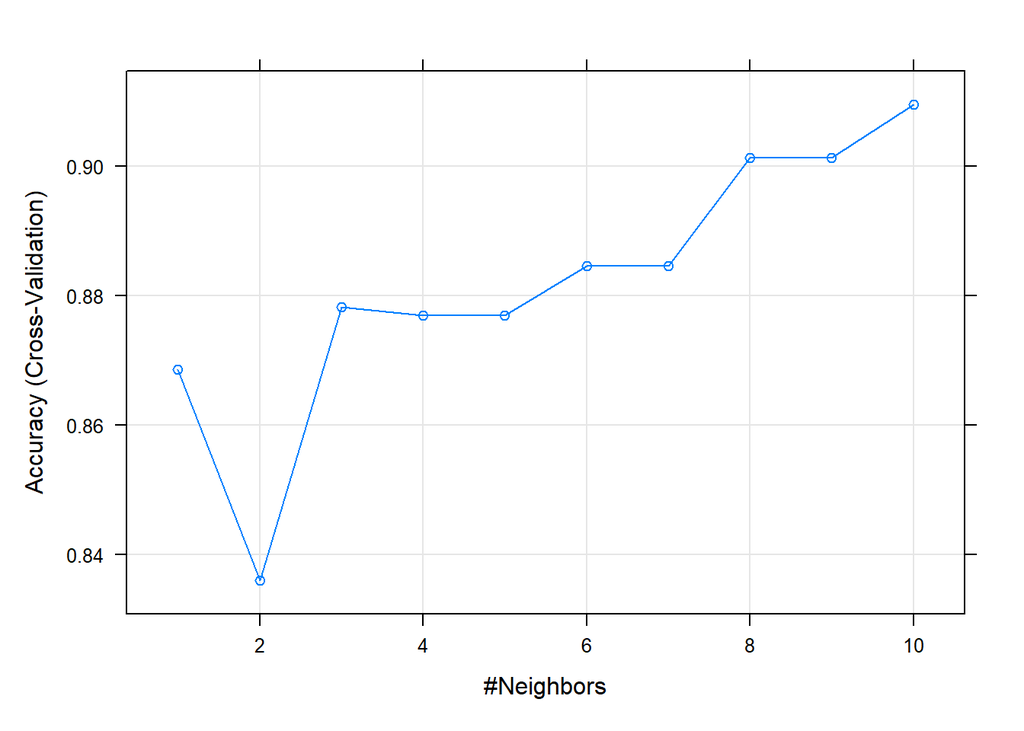

```r
allRegionKnnModel <- train(Classes ~ ., data=allRegionTrainData, method="knn",  tuneGrid=expand.grid(k = 1:10), trControl=LRspecs)


plot(allRegionKnnModel)
```

```r
allRegionKnnModel
## k-Nearest Neighbors
##
## 122 samples
##  13 predictor
##   2 classes: 'fire', 'not_fire'
##
## No pre-processing
## Resampling: Cross-Validated (10 fold)
## Summary of sample sizes: 110, 109, 110, 109, 110, 110, ...
## Resampling results across tuning parameters:
##
##   k   Accuracy   Kappa
##    1  0.8685897  0.7038942
##    2  0.8358974  0.6434944
##    3  0.8782051  0.7280471
##    4  0.8769231  0.7251252
##    5  0.8769231  0.7227967
##    6  0.8846154  0.7363007
##    7  0.8846154  0.7414439
##    8  0.9012821  0.7737968
##    9  0.9012821  0.7809396
##   10  0.9096154  0.7980825
##
## Accuracy was used to select the optimal model using the largest value.
## The final value used for the model was k = 10.

predictions = predict(allRegionKnnModel, newdata = allRegionTestData)
knn1MatrixR = confusionMatrix(data=predictions,allRegionTestData$Classes)

knn1MatrixR
## Confusion Matrix and Statistics
##
##           Reference
## Prediction fire not_fire
##   fire       57       12
##   not_fire    4       49
##
##                Accuracy : 0.8689
##                  95% CI : (0.7958, 0.9231)
##     No Information Rate : 0.5
##     P-Value [Acc > NIR] : < 2e-16
##
##                   Kappa : 0.7377
##
##  Mcnemar's Test P-Value : 0.08012
##
##             Sensitivity : 0.9344
##             Specificity : 0.8033
##          Pos Pred Value : 0.8261
##          Neg Pred Value : 0.9245
##              Prevalence : 0.5000
##          Detection Rate : 0.4672
##    Detection Prevalence : 0.5656
##       Balanced Accuracy : 0.8689
##
##        'Positive' Class : fire
##
knn1MatrixR$byClass
```

```
##          Sensitivity          Specificity       Pos Pred Value
##            0.9344262            0.8032787            0.8260870
##       Neg Pred Value            Precision               Recall
##            0.9245283            0.8260870            0.9344262
##                   F1           Prevalence       Detection Rate
##            0.8769231            0.5000000            0.4672131
## Detection Prevalence    Balanced Accuracy
##            0.5655738            0.8688525
```

The optimal k that was chosen is k=10. It gives 86.8% accuracy, 93.4% recall and 82.6% precision. The results decreased since we are now using a larger dataset, but we expect these results can improve further when we apply feature selection.

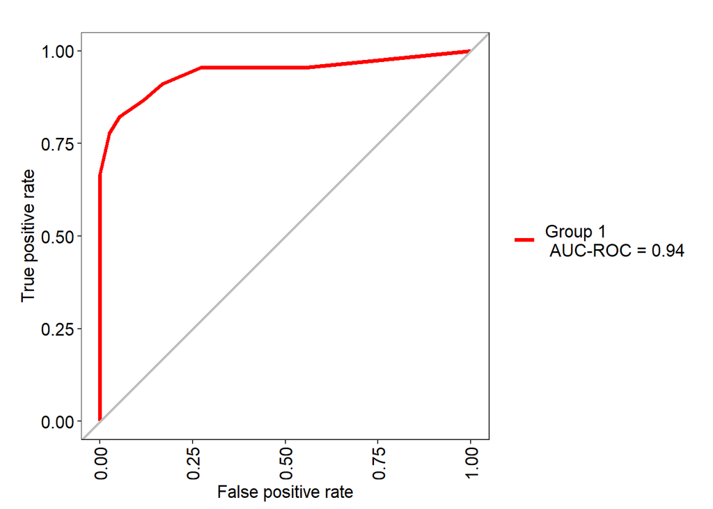

```r
ROCKNN = evalm(allRegionKnnModel, plots = c("r"))
## ***MLeval: Machine Learning Model Evaluation***
## Input: caret train function object
## Not averaging probs.
## Group 1 type: cv
## Observations: 122
## Number of groups: 1
## Observations per group: 122
## Positive: not_fire
## Negative: fire
## Group: Group 1
## Positive: 45
## Negative: 77
## ***Performance Metrics***
## Group 1 Optimal Informedness = 0.77027417027417
## Group 1 AUC-ROC = 0.94
```

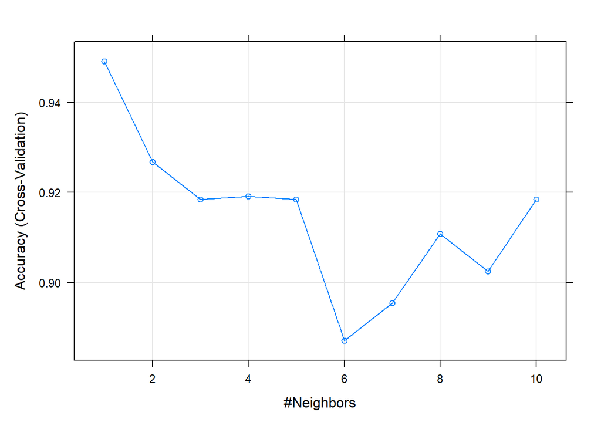

```r
allRegionKnnModel <- train(Classes ~ Temperature+Rain+FFMC+DMC+DC+ISI+BUI+FWI, data=allRegionTrainData, method="knn",  tuneGrid=expand.grid(k = 1:10), trControl=LRspecs)

plot(allRegionKnnModel)
```

```r
allRegionKnnModel
## k-Nearest Neighbors
##
## 122 samples
##   8 predictor
##   2 classes: 'fire', 'not_fire'
##
## No pre-processing
## Resampling: Cross-Validated (10 fold)
## Summary of sample sizes: 109, 111, 109, 110, 110, 110, ...
## Resampling results across tuning parameters:
##
##   k   Accuracy   Kappa
##    1  0.9491259  0.8894324
##    2  0.9268065  0.8433690
##    3  0.9184732  0.8157661
##    4  0.9191142  0.8168294
##    5  0.9184732  0.8159145
##    6  0.8870629  0.7461465
##    7  0.8953963  0.7665314
##    8  0.9107809  0.8002976
##    9  0.9024476  0.7802976
##   10  0.9184732  0.8111231
##
## Accuracy was used to select the optimal model using the largest value.
## The final value used for the model was k = 1.

predictions = predict(allRegionKnnModel, newdata = allRegionTestData)

knn2MatrixR = confusionMatrix(data=predictions,allRegionTestData$Classes)

knn2MatrixR
## Confusion Matrix and Statistics
##
##           Reference
## Prediction fire not_fire
##   fire       60        3
##   not_fire    1       58
##
##                Accuracy : 0.9672
##                  95% CI : (0.9182, 0.991)
##     No Information Rate : 0.5
##     P-Value [Acc > NIR] : <2e-16
##
##                   Kappa : 0.9344
##
##  Mcnemar's Test P-Value : 0.6171
##
##             Sensitivity : 0.9836
##             Specificity : 0.9508
##          Pos Pred Value : 0.9524
##          Neg Pred Value : 0.9831
##              Prevalence : 0.5000
##          Detection Rate : 0.4918
##    Detection Prevalence : 0.5164
##       Balanced Accuracy : 0.9672
##
##        'Positive' Class : fire
##
knn2MatrixR$byClass
```

```
##          Sensitivity          Specificity       Pos Pred Value
##            0.9836066            0.9508197            0.9523810
##       Neg Pred Value            Precision               Recall
##            0.9830508            0.9523810            0.9836066
##                   F1           Prevalence       Detection Rate
##            0.9677419            0.5000000            0.4918033
## Detection Prevalence    Balanced Accuracy
##            0.5163934            0.9672131
```

The optimal k this time is k=1, and as expected, the results have improved. Accuracy increased to 96.7%, recall increased to 98.3% and precision increased to 95.2%.

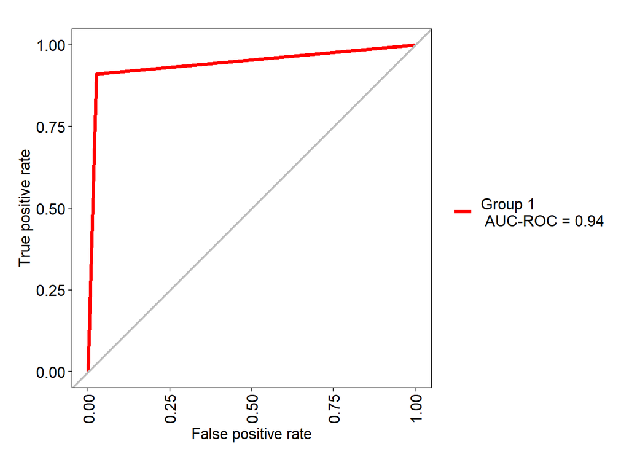

```r
ROCKNN = evalm(allRegionKnnModel, plots = c("r"))
## ***MLeval: Machine Learning Model Evaluation***
## Input: caret train function object
## Not averaging probs.
## Group 1 type: cv
## Observations: 122
## Number of groups: 1
## Observations per group: 122
## Positive: not_fire
## Negative: fire
## Group: Group 1
## Positive: 45
## Negative: 77
## ***Performance Metrics***
## Group 1 Optimal Informedness = 0.885137085137085
## Group 1 AUC-ROC = 0.94
```

## Tree-Based Methods

We apply the various tree-based methods on the whole region only, since that is what we will use in our comparison.

### Bagging

```r
library(rsample)
library(caret)

set.seed(55)

bagging <- train(Classes~., data=allRegionTrainData, method="treebag", metric="Accuracy", trControl=LRspecs)
#bagging
bagging
## Bagged CART
##
## 122 samples
##  13 predictor
##   2 classes: 'fire', 'not_fire'
##
## No pre-processing
## Resampling: Cross-Validated (10 fold)
## Summary of sample sizes: 110, 110, 111, 110, 109, 109, ...
## Resampling results:
##
##   Accuracy   Kappa
##   0.9596154  0.9121601

predictions = predict(bagging, newdata = allRegionTestData)

baggingMatrix1 = confusionMatrix(data=predictions,allRegionTestData$Classes)
baggingMatrix1
## Confusion Matrix and Statistics
##
##           Reference
## Prediction fire not_fire
##   fire       58        0
##   not_fire    3       61
##
##                Accuracy : 0.9754
##                  95% CI : (0.9298, 0.9949)
##     No Information Rate : 0.5
##     P-Value [Acc > NIR] : <2e-16
##
##                   Kappa : 0.9508
##
##  Mcnemar's Test P-Value : 0.2482
##
##             Sensitivity : 0.9508
##             Specificity : 1.0000
##          Pos Pred Value : 1.0000
##          Neg Pred Value : 0.9531
##              Prevalence : 0.5000
##          Detection Rate : 0.4754
##    Detection Prevalence : 0.4754
##       Balanced Accuracy : 0.9754
##
##        'Positive' Class : fire
##
baggingMatrix1$byClass
```

```
##          Sensitivity          Specificity       Pos Pred Value
##            0.9508197            1.0000000            1.0000000
##       Neg Pred Value            Precision               Recall
##            0.9531250            1.0000000            0.9508197
##                   F1           Prevalence       Detection Rate
##            0.9747899            0.5000000            0.4754098
## Detection Prevalence    Balanced Accuracy
##            0.4754098            0.9754098
```

Bagging did a great job with a 97.5% accuracy, 100% precision and 95% recall. We will not apply feature selection as the results are already good.

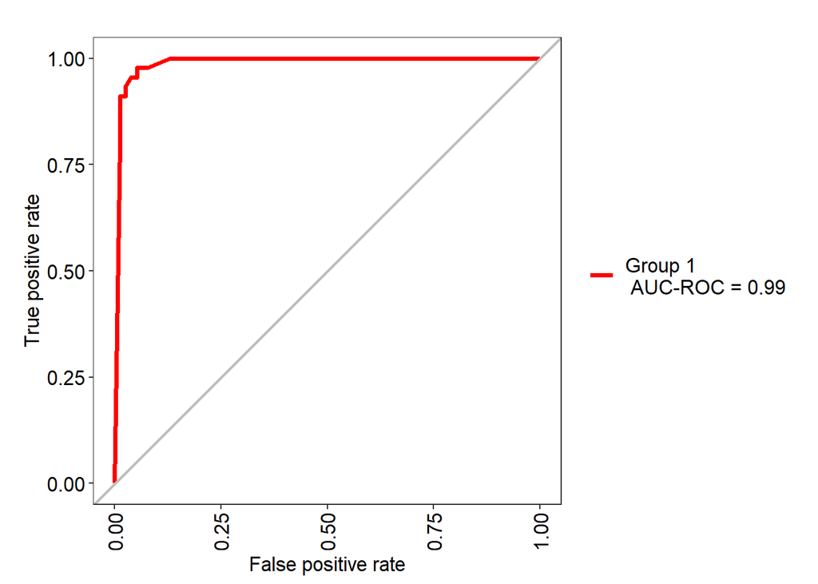

```r
ROCBagging = evalm(bagging, plots = c("r"))
## ***MLeval: Machine Learning Model Evaluation***
## Input: caret train function object
## Not averaging probs.
## Group 1 type: cv
## Observations: 122
## Number of groups: 1
## Observations per group: 122
## Positive: not_fire
## Negative: fire
## Group: Group 1
## Positive: 45
## Negative: 77
## ***Performance Metrics***
## Group 1 Optimal Informedness = 0.925829725829726
## Group 1 AUC-ROC = 0.99
```

### Random forest

```r
set.seed(55)

randomForest <- train(Classes~., data=allRegionTrainData, method="rf", metric="Accuracy", trControl=LRspecs)
#random forest
randomForest
## Random Forest
##
## 122 samples
##  13 predictor
##   2 classes: 'fire', 'not_fire'
##
## No pre-processing
## Resampling: Cross-Validated (10 fold)
## Summary of sample sizes: 110, 110, 111, 110, 109, 109, ...
## Resampling results across tuning parameters:
##
##   mtry  Accuracy   Kappa
##    2    0.9588578  0.9111631
##    7    0.9665501  0.9259356
##   13    0.9582168  0.9082885
##
## Accuracy was used to select the optimal model using the largest value.
## The final value used for the model was mtry = 7.

predictions = predict(randomForest, newdata = allRegionTestData)

rfMatrix1 = confusionMatrix(data=predictions,allRegionTestData$Classes)
rfMatrix1
## Confusion Matrix and Statistics
##
##           Reference
## Prediction fire not_fire
##   fire       58        0
##   not_fire    3       61
##
##                Accuracy : 0.9754
##                  95% CI : (0.9298, 0.9949)
##     No Information Rate : 0.5
##     P-Value [Acc > NIR] : <2e-16
##
##                   Kappa : 0.9508
##
##  Mcnemar's Test P-Value : 0.2482
##
##             Sensitivity : 0.9508
##             Specificity : 1.0000
##          Pos Pred Value : 1.0000
##          Neg Pred Value : 0.9531
##              Prevalence : 0.5000
##          Detection Rate : 0.4754
##    Detection Prevalence : 0.4754
##       Balanced Accuracy : 0.9754
##
##        'Positive' Class : fire
##
rfMatrix1$byClass
```

```
##          Sensitivity          Specificity       Pos Pred Value
##            0.9508197            1.0000000            1.0000000
##       Neg Pred Value            Precision               Recall
##            0.9531250            1.0000000            0.9508197
##                   F1           Prevalence       Detection Rate
##            0.9747899            0.5000000            0.4754098
## Detection Prevalence    Balanced Accuracy
##            0.4754098            0.9754098
```

The results are exactly like those of bagging. This might be due to the fact that we don’t have many features, and random forest is actually an extension over bagging.

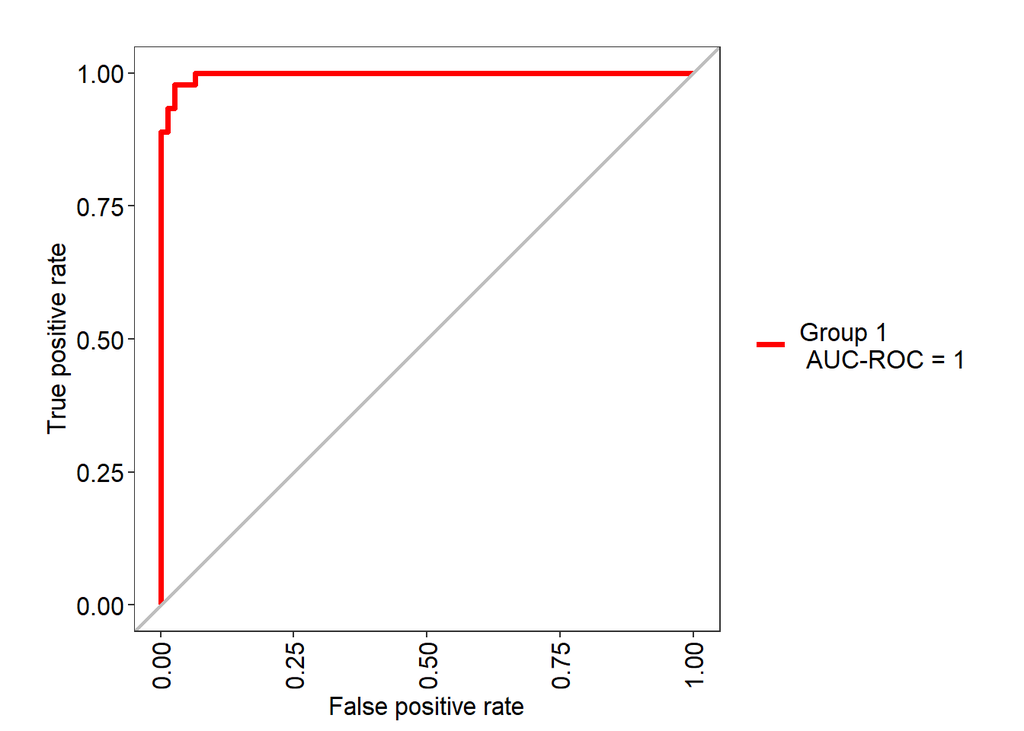

```r
ROCBagging = evalm(randomForest, plots = c("r"))
## ***MLeval: Machine Learning Model Evaluation***
## Input: caret train function object
## Not averaging probs.
## Group 1 type: cv
## Observations: 122
## Number of groups: 1
## Observations per group: 122
## Positive: not_fire
## Negative: fire
## Group: Group 1
## Positive: 45
## Negative: 77
## ***Performance Metrics***
## Group 1 Optimal Informedness = 0.951803751803752
## Group 1 AUC-ROC = 1
```

### Boosting

```r
suppressWarnings({
library(C50)
set.seed(55)

boosting <- train(Classes~., data=allRegionTrainData, method="C5.0", metric="Accuracy", trControl=LRspecs)
#C5.0 is an example on boosting
boosting

})
## C5.0
##
## 122 samples
##  13 predictor
##   2 classes: 'fire', 'not_fire'
##
## No pre-processing
## Resampling: Cross-Validated (10 fold)
## Summary of sample sizes: 110, 110, 111, 110, 109, 109, ...
## Resampling results across tuning parameters:
##
##   model  winnow  trials  Accuracy   Kappa
##   rules  FALSE    1      0.9491259  0.8885371
##   rules  FALSE   10      0.9491259  0.8885371
##   rules  FALSE   20      0.9491259  0.8885371
##   rules   TRUE    1      0.9582168  0.9127521
##   rules   TRUE   10      0.9401515  0.8654202
##   rules   TRUE   20      0.9401515  0.8654202
##   tree   FALSE    1      0.9491259  0.8885371
##   tree   FALSE   10      0.9491259  0.8885371
##   tree   FALSE   20      0.9491259  0.8885371
##   tree    TRUE    1      0.9659091  0.9284148
##   tree    TRUE   10      0.9401515  0.8654202
##   tree    TRUE   20      0.9401515  0.8654202
##
## Accuracy was used to select the optimal model using the largest value.
## The final values used for the model were trials = 1, model = tree and winnow
##  = TRUE.
```

```r
predictions = predict(boosting, newdata = allRegionTestData)

boostingMatrix1 = confusionMatrix(data=predictions,allRegionTestData$Classes)
boostingMatrix1
## Confusion Matrix and Statistics
##
##           Reference
## Prediction fire not_fire
##   fire       60        1
##   not_fire    1       60
##
##                Accuracy : 0.9836
##                  95% CI : (0.942, 0.998)
##     No Information Rate : 0.5
##     P-Value [Acc > NIR] : <2e-16
##
##                   Kappa : 0.9672
##
##  Mcnemar's Test P-Value : 1
##
##             Sensitivity : 0.9836
##             Specificity : 0.9836
##          Pos Pred Value : 0.9836
##          Neg Pred Value : 0.9836
##              Prevalence : 0.5000
##          Detection Rate : 0.4918
##    Detection Prevalence : 0.5000
##       Balanced Accuracy : 0.9836
##
##        'Positive' Class : fire
##
boostingMatrix1$byClass
```

```
##          Sensitivity          Specificity       Pos Pred Value
##            0.9836066            0.9836066            0.9836066
##       Neg Pred Value            Precision               Recall
##            0.9836066            0.9836066            0.9836066
##                   F1           Prevalence       Detection Rate
##            0.9836066            0.5000000            0.4918033
## Detection Prevalence    Balanced Accuracy
##            0.5000000            0.9836066
```

Boosting results were even better than the previous models, achieving 98.3% accuracy, precision and recall.

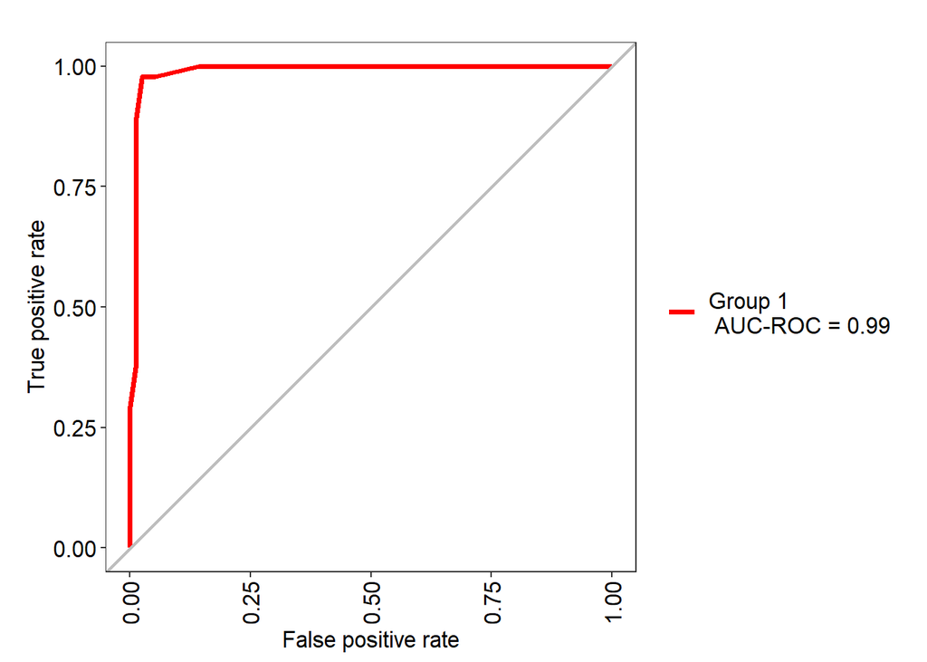

```r
ROCBagging = evalm(boosting, plots = c("r"))
## ***MLeval: Machine Learning Model Evaluation***
## Input: caret train function object
## Not averaging probs.
## Group 1 type: cv
## Observations: 122
## Number of groups: 1
## Observations per group: 122
## Positive: not_fire
## Negative: fire
## Group: Group 1
## Positive: 45
## Negative: 77
## ***Performance Metrics***
## Group 1 Optimal Informedness = 0.951803751803752
## Group 1 AUC-ROC = 0.99
```

## Conclusion

| Model | AUC-ROC |
| --- | --- |
| Logistic Regression | 0.91 |
| LDA (Feature Selection) | 0.51 |
| QDA (Feature Selection) | 0.99 |
| KNN (Feature Selection) | 0.94 |
| Bagging | 0.99 |
| Random Forest | 1 |
| Boosting | 0.99 |